# Lecture 1 – *R* and *Bioconductor*

Martin Morgan

20 June 2022

# 1 *R*

## 1.1 History

- Statistical programming language
- ‘Free’ software: no cost, open source, broad use
- Extensible: packages (>18,000 on [CRAN](https://cran.r-project.org), >2,100 on [Bioconductor](https://bioconductor.org))
- Key features
  - Intrinsic *statistical* concepts, e.g., missing values, factors
  - *Vectorized* computation
  - ‘Old-school’ scripts emaphasized more than graphical user interfaces – great for reproducibility!
  - (Advanced) *copy-on-change* semanatics

## 1.2 Vectors and data frames

```r
1 + 2
```

```
## [1] 3
```

```r
x = c(1, 2, 3)
1:3             # sequence of integers from 1 to 3
```

```
## [1] 1 2 3
```

```r
x + c(4, 5, 6)  # vectorized
```

```
## [1] 5 7 9
```

```r
x + 4           # recycling
```

```
## [1] 5 6 7
```

Vectors

- `numeric()`, `character()`, `logical()`, `integer()`, `complex()`, …
- `NA`: ‘not available’
- `factor()`: values from restricted set of ‘levels’.

Operations

- numeric: `==`, `<`, `<=`, `>`, `>=`, …
- logical: `|` (or), `&` (and), `!` (not)
- subset: `[`, e.g., `x[c(2, 3)]`
- assignment: `[<-`, e.g., `x[c(1, 3)] = x[c(1, 3)]`
- other: `is.na()`

Functions

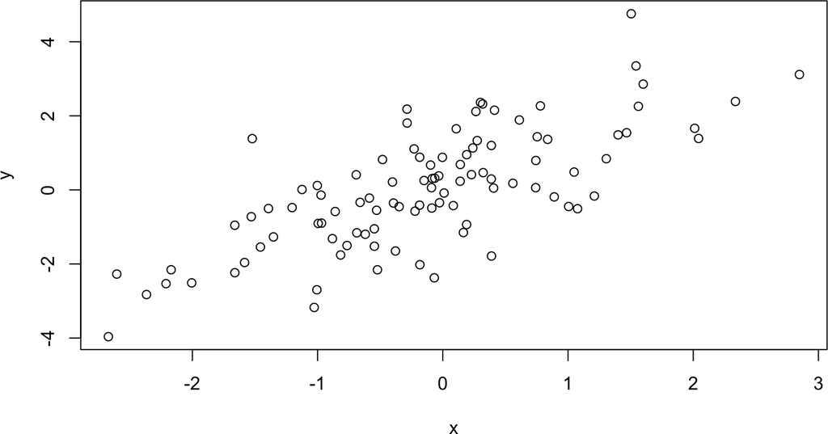

```r
x = rnorm(100)
y = x + rnorm(100)
plot(x, y)
```

- Many!

`data.frame`

```r
df <- data.frame(Independent = x, Dependent = y)
head(df)
```

```
##   Independent Dependent
## 1   1.5620127  2.257045
## 2   0.8373360  1.364762
## 3   0.6114359  1.888833
## 4  -0.2294786  1.107088
## 5  -0.2860413  2.180873
## 6   0.2643727  2.117244
```

```r
df[1:5, 1:2]
```

```
##   Independent Dependent
## 1   1.5620127  2.257045
## 2   0.8373360  1.364762
## 3   0.6114359  1.888833
## 4  -0.2294786  1.107088
## 5  -0.2860413  2.180873
```

```r
df[1:5, ]
```

```
##   Independent Dependent
## 1   1.5620127  2.257045
## 2   0.8373360  1.364762
## 3   0.6114359  1.888833
## 4  -0.2294786  1.107088
## 5  -0.2860413  2.180873
```

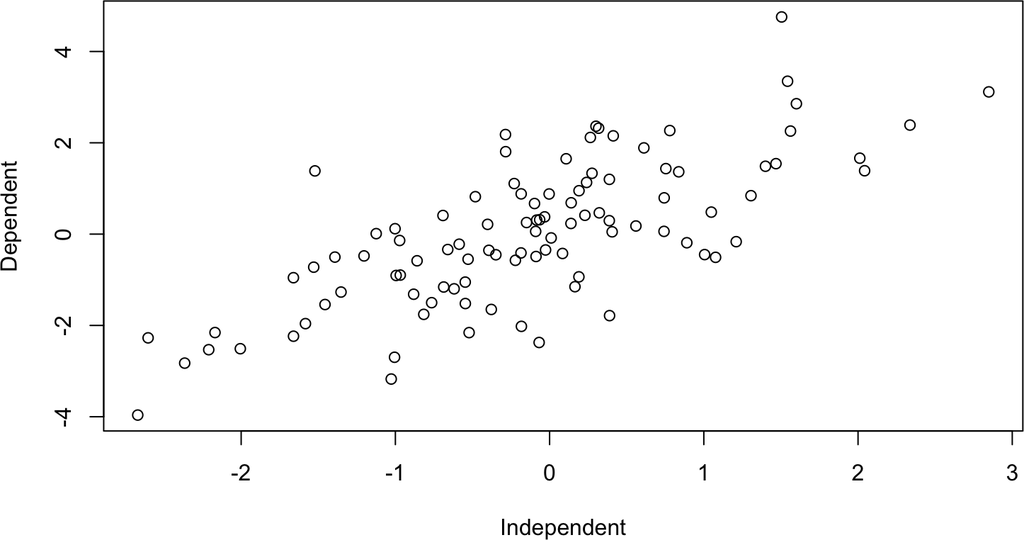

```r
plot(Dependent ~ Independent, df)  # 'formula' interface
```

- List of equal-length vectors
- Vectors can be of different type
- Two-dimensional subset and assignment
- Column access: `df[, 1]`, `df[, "Independent"]`, `df[[1]]`, `df[["Independent"]]`, `df$Independent`

Exercise: plot only values with `Dependent > 0`, `Independent > 0`

1. Select rows

   ```r
   ridx <- (df$Dependent > 0) & (df$Independent > 0)
   ```

2. Plot subset

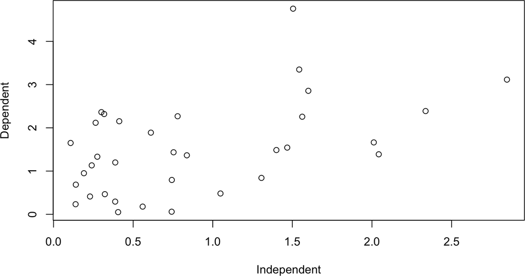

   ```r
   plot(Dependent ~ Independent, df[ridx, ])
   ```

3. Skin the cat another way

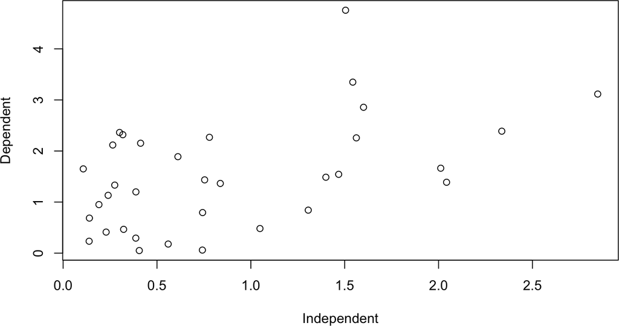

   ```r
   plot(
       Dependent ~ Independent, df,
       subset = (Dependent > 0) & (Independent > 0)
   )
   ```

## 1.3 Analysis: functions, classes, methods

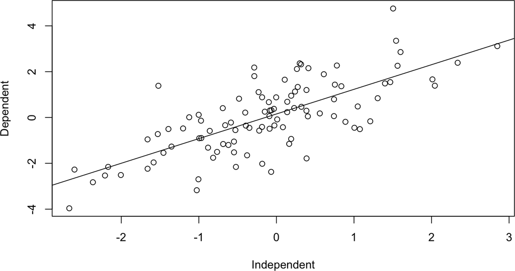

```r
fit <- lm(Dependent ~ Independent, df)  # linear model -- regression
anova(fit)                              # summary table
## Analysis of Variance Table
##
## Response: Dependent
##             Df Sum Sq Mean Sq F value    Pr(>F)
## Independent  1 131.83 131.828  111.15 < 2.2e-16 ***
## Residuals   98 116.23   1.186
## ---
## Signif. codes:  0 '***' 0.001 '**' 0.01 '*' 0.05 '.' 0.1 ' ' 1
plot(Dependent ~ Independent, df)
abline(fit)
```

- `lm()`: plain-old function
- `fit`: an *object* of class “lm”
- `anova()`: a *generic* with a specific *method* for class “lm”

```r
class(fit)
```

```
## [1] "lm"
```

```r
methods(class="lm")
```

```
##  [1] add1           alias          anova          case.names     coerce
##  [6] confint        cooks.distance deviance       dfbeta         dfbetas
## [11] drop1          dummy.coef     effects        extractAIC     family
## [16] formula        hatvalues      influence      initialize     kappa
## [21] labels         logLik         model.frame    model.matrix   nobs
## [26] plot           predict        print          proj           qr
## [31] residuals      rstandard      rstudent       show           simulate
## [36] slotsFromS3    summary        variable.names vcov
## see '?methods' for accessing help and source code
```

## 1.4 Help!

```r
?"plot"          # plain-old-function or generic
?"plot.formula"  # method
```

## 1.5 Packages

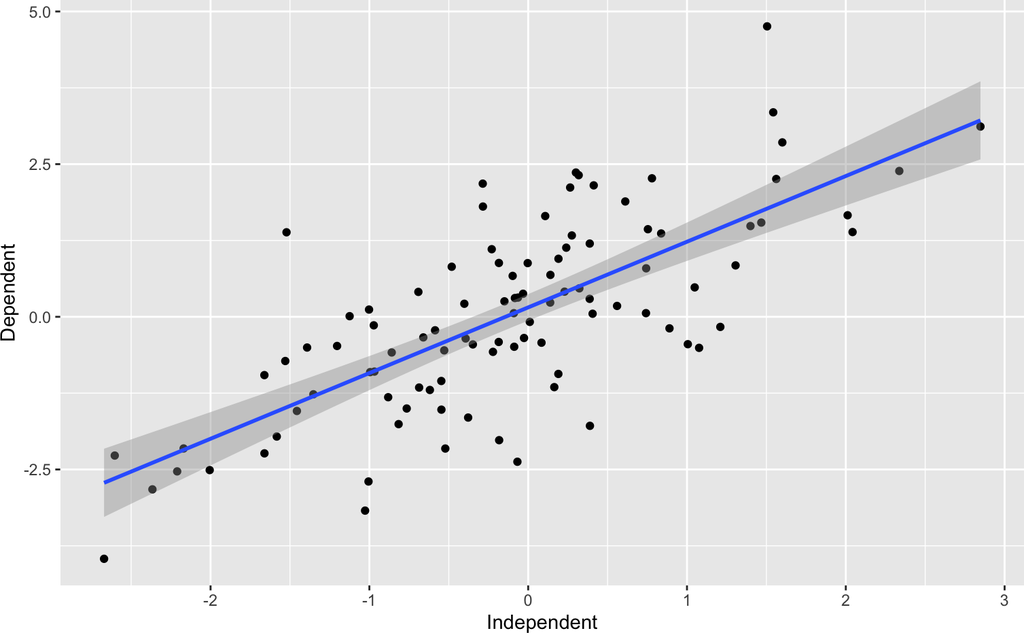

```r
library(ggplot2)
ggplot(df) +
    aes(x = Independent, y = Dependent) +
    geom_point() +
    geom_smooth(method = "lm")
## `geom_smooth()` using formula 'y ~ x'
```

- General purpose: >18,000 packages on [CRAN](https://cran.r-project.org)
- Gain contributor’s domain expertise *and* weird (or other) idiosyncracies
- *Installation* (once only per computer) versus *load* (via `library(ggplot2)`, once per session)

# 2 *Bioconductor*

## 2.1 History

Started 2002 as a platform for understanding analysis of microarray data

More than 2,100 packages. Domains of expertise:

- Sequencing (Single-cell, RNASeq, ChIPSeq, single-cell, called variants, …)
- Microarrays (methylation, expression, copy number, …)
- flow cytometry
- proteomics
- …

Important themes

- Reproducible research
- Interoperability between packages & work flows
- Usability

Resources

- https://bioconductor.org
- https://bioconductor.org/packages – software, annotation, experiment, workflow
- https://support.bioconductor.org – questions and problems

## 2.2 High-throughput genomic analysis

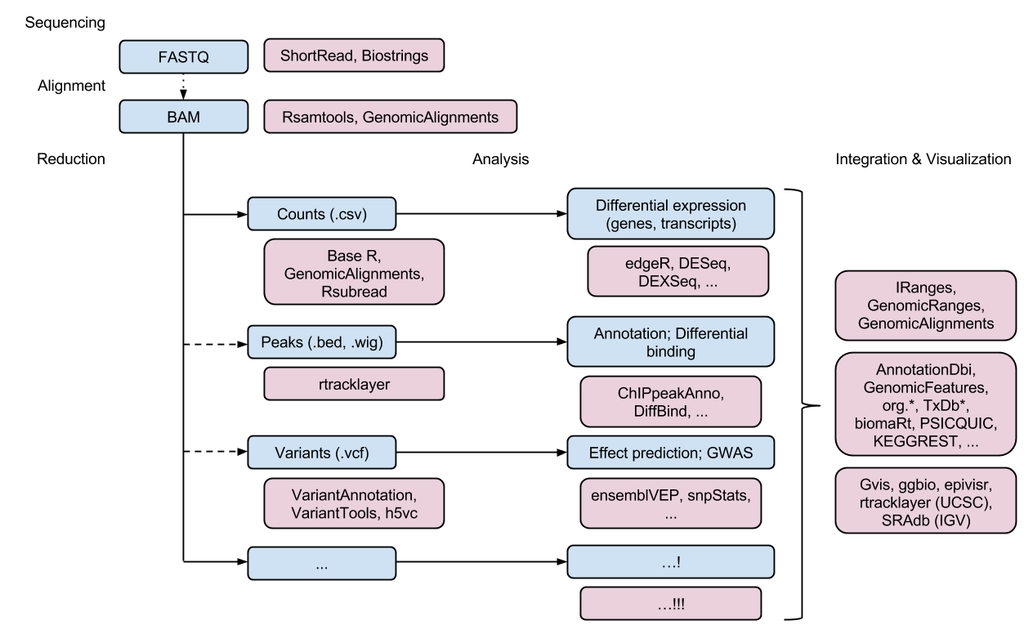

## 2.3 DNA sequences

Biostrings themes

- *Valid* data, e.g., alphabet
- ‘Vector’ interface: `length()`, `[`, …
- Specialized operations, e.g,. `reverseComplement()`

```r
library(Biostrings)

dna <- DNAStringSet(c("AAACTG", "CCCTTCAAC", "TACGAA"))
dna
## DNAStringSet object of length 3:
##     width seq
## [1]     6 AAACTG
## [2]     9 CCCTTCAAC
## [3]     6 TACGAA

length(dna)
```

```
## [1] 3
```

```r
dna[c(1, 3, 1)]
## DNAStringSet object of length 3:
##     width seq
## [1]     6 AAACTG
## [2]     6 TACGAA
## [3]     6 AAACTG

width(dna)
```

```
## [1] 6 9 6
```

```r
reverseComplement(dna)
## DNAStringSet object of length 3:
##     width seq
## [1]     6 CAGTTT
## [2]     9 GTTGAAGGG
## [3]     6 TTCGTA
```

Help!

```r
methods(class="DNAStringSet")
?"DNAStringSet"
browseVignettes(package="Biostrings")
```

## 2.4 Genomic ranges

GenomicRanges

- Data (e.g., aligned reads, called peaks, copy number)
- Annotations (e.g., genes, exons, transcripts)
- Close relation to BED files (see `rtracklayer::import.bed()` and HelloRanges)
- Also vector interface – `length()`, `[`, etc.

```r
library(GenomicRanges)

gr <- GRanges(c("chr1:100-120", "chr1:115-130", "chr2:200-220"))
gr
## GRanges object with 3 ranges and 0 metadata columns:
##       seqnames    ranges strand
##          <Rle> <IRanges>  <Rle>
##   [1]     chr1   100-120      *
##   [2]     chr1   115-130      *
##   [3]     chr2   200-220      *
##   -------
##   seqinfo: 2 sequences from an unspecified genome; no seqlengths
```

Intra-range operations

- e.g., `shift()`, `narrow()`, `flank()`

Inter-range operations

- e.g., `reduce()`, `coverage()`, `gaps()`, `disjoin()`

Between-range operations

- e.g., `countOverlaps()`, `findOverlaps()`, `summarizeOverlaps()`

```r
shift(gr, 1)
## GRanges object with 3 ranges and 0 metadata columns:
##       seqnames    ranges strand
##          <Rle> <IRanges>  <Rle>
##   [1]     chr1   101-121      *
##   [2]     chr1   116-131      *
##   [3]     chr2   201-221      *
##   -------
##   seqinfo: 2 sequences from an unspecified genome; no seqlengths

reduce(gr)
## GRanges object with 2 ranges and 0 metadata columns:
##       seqnames    ranges strand
##          <Rle> <IRanges>  <Rle>
##   [1]     chr1   100-130      *
##   [2]     chr2   200-220      *
##   -------
##   seqinfo: 2 sequences from an unspecified genome; no seqlengths

anno <- GRanges(c("chr1:110-150", "chr2:150-210"))
countOverlaps(anno, gr)
```

```
## [1] 2 1
```

Help!

```r
methods(class="GRanges")
methods(class="GRangesList")
?"GRanges"
?"GRangesList"
browseVignettes(package="GenomicRanges")
```

Lists of Genomic Ranges

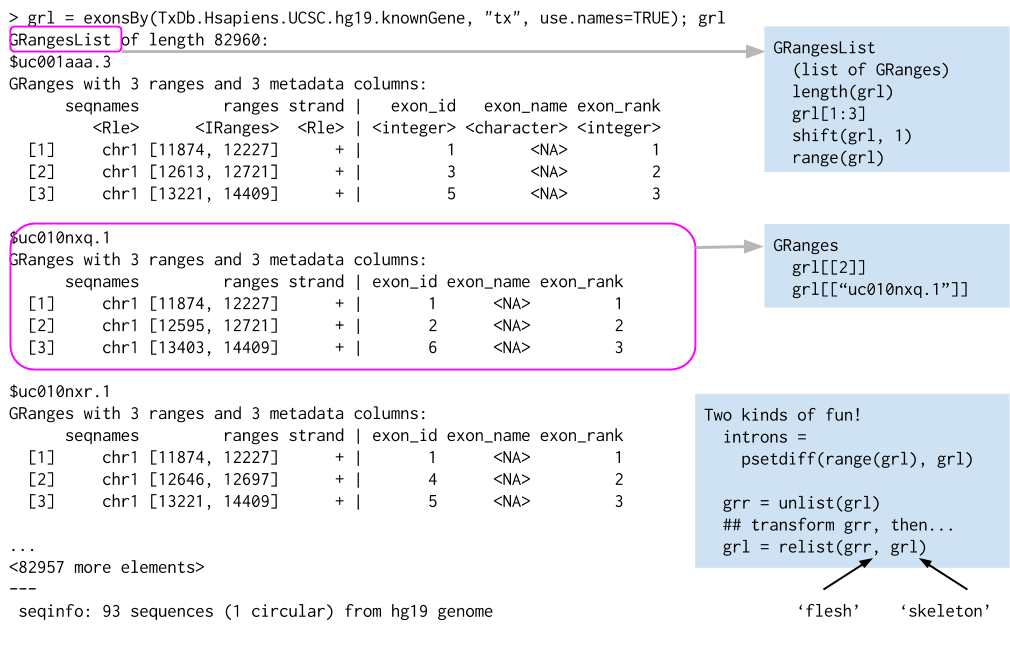

- e.g., exons-within-transcripts, alignments-within-reads

## 2.5 Summarized experiments

Component parts

- three components – underlying ‘matrix’, ‘row’ annotations (genomic features), ‘column’ annotations (sample descriptions)

```r
counts <- read.csv("lecture-01-data/airway_counts.csv", row.names=1)
counts <- as.matrix(counts)
head(counts, 3)
```

```
##                 SRR1039508 SRR1039509 SRR1039512 SRR1039513 SRR1039516
## ENSG00000000003        679        448        873        408       1138
## ENSG00000000419        467        515        621        365        587
## ENSG00000000457        260        211        263        164        245
##                 SRR1039517 SRR1039520 SRR1039521
## ENSG00000000003       1047        770        572
## ENSG00000000419        799        417        508
## ENSG00000000457        331        233        229
```

```r
colData <- read.csv("lecture-01-data/airway_colData.csv", row.names=1)
colData[, 1:4]
```

```
##            SampleName    cell   dex albut
## SRR1039508 GSM1275862  N61311 untrt untrt
## SRR1039509 GSM1275863  N61311   trt untrt
## SRR1039512 GSM1275866 N052611 untrt untrt
## SRR1039513 GSM1275867 N052611   trt untrt
## SRR1039516 GSM1275870 N080611 untrt untrt
## SRR1039517 GSM1275871 N080611   trt untrt
## SRR1039520 GSM1275874 N061011 untrt untrt
## SRR1039521 GSM1275875 N061011   trt untrt
```

```r
rowRanges <- readRDS("lecture-01-data/airway_rowRanges.rds")
rowRanges
## GRangesList object of length 33469:
## $ENSG00000000003
## GRanges object with 17 ranges and 2 metadata columns:
##        seqnames            ranges strand |   exon_id       exon_name
##           <Rle>         <IRanges>  <Rle> | <integer>     <character>
##    [1]        X 99883667-99884983      - |    667145 ENSE00001459322
##    [2]        X 99885756-99885863      - |    667146 ENSE00000868868
##    [3]        X 99887482-99887565      - |    667147 ENSE00000401072
##    [4]        X 99887538-99887565      - |    667148 ENSE00001849132
##    [5]        X 99888402-99888536      - |    667149 ENSE00003554016
##    ...      ...               ...    ... .       ...             ...
##   [13]        X 99890555-99890743      - |    667156 ENSE00003512331
##   [14]        X 99891188-99891686      - |    667158 ENSE00001886883
##   [15]        X 99891605-99891803      - |    667159 ENSE00001855382
##   [16]        X 99891790-99892101      - |    667160 ENSE00001863395
##   [17]        X 99894942-99894988      - |    667161 ENSE00001828996
##   -------
##   seqinfo: 722 sequences (1 circular) from an unspecified genome
##
## ...
## <33468 more elements>
```

Could manipulate independently…

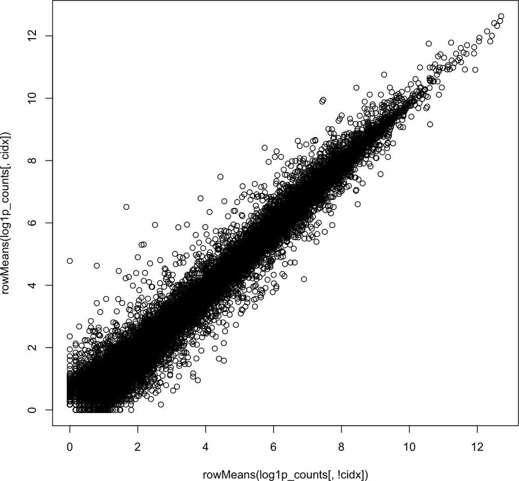

```r
cidx <- colData$dex == "trt"
log1p_counts <- log1p(counts)
plot(rowMeans(log1p_counts[,cidx]) ~ rowMeans(log1p_counts[,!cidx]))
```

- very fragile, e.g., what if `colData` rows had been re-ordered?

Solution: coordinate in a single object – SummarizedExperiment

```r
library(SummarizedExperiment)

se <- SummarizedExperiment(
    assays = list(counts = counts),
    rowRanges = rowRanges, colData = colData
)
assay(se, "log1p_counts") <- log1p(assay(se, "counts"))
## manipulate rows and columns in a coordinated fashion...
```

- Much more robust to ‘bookkeeping’ errors
- matrix-like interface: `dim()`, two-dimensional `[`, …
- accessors: `assay()`, `rowData()` / `rowRanges()`, `colData()`, …

Help!

```r
methods(class="SummarizedExperiment")
?"SummarizedExperiment"
browseVignettes(package="SummarizedExperiment")
```

## 2.6 Packages for high-throughput genomic analysis

Web site, https://bioconductor.org

Support site, https://support.bioconductor.org

2140 ‘software’ packages, https://bioconductor.org/packages

- Sequence analysis (Single-cell, RNASeq, ChIPSeq, called variants, copy number, …)
- Microarrays (methylation, copy number, classical expression, …)
- Annotation (more about annotations later this morning…)
- Flow cytometry
- Proteomics, image analysis, …

Discovery and use, e.g., DESeq2

- https://bioconductor.org/packages
- Landing pages: title, description (abstract), installation instructions, badges
- Vignettes!
- [Workflows](https://bioconductor.org/packages/release/BiocViews.html#___Workflow), [course material](https://bioconductor.org/help/course-materials/), [videos](https://www.youtube.com/user/bioconductor), …

Single-cell analysis

- Check out [Orchestrating Single-Cell Analysis with Bioconductor](https://bioconductor.org/books/release/OSCA/)!

# 3 End matter

## Acknowledgements

Research reported in this tutorial is supported by the National Human Genome Research Institute and the National Cancer Institute of the National Institutes of Health under award numbers U24HG004059 (Bioconductor), U24HG010263 (AnVIL) and U24CA180996 (ITCR).